# Introduction to Machine Learning - Exercises, Part 1 and 2

## Exercise 4 (kernel regression estimate)

1. Generate $n=500$ observations $(X_1,Y_1),\dots,(X_n,Y_n)$ according to the model above.

```r
n <- 500
set.seed(1234)
X <- runif(n,-2*pi,2*pi)
set.seed(5678)
eps <- rnorm(n,0,0.2)
Y <- sin(X)+eps
df <- data.frame(X=X,Y=Y)
```

2. Represent on a graph both the sample and the sine function.

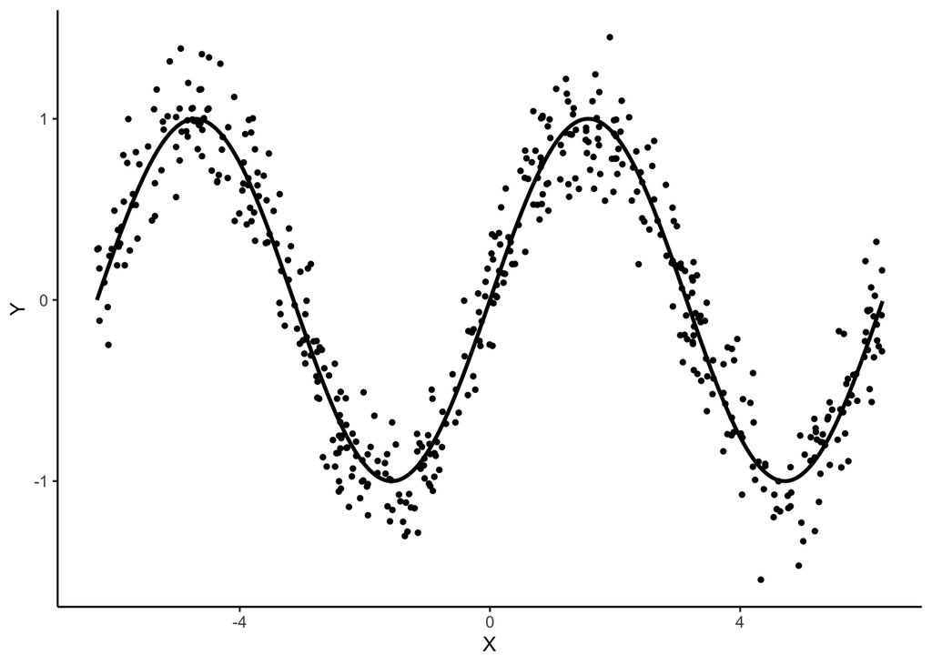

```r
x <- seq(-2*pi,2*pi,by=0.01)
df1 <- data.frame(x=x,y=sin(x))
g1 <- ggplot(df)+aes(x=X,y=Y)+geom_point(size=1)+
  geom_line(data=df1,aes(x=x,y=y),color="black",size=1)+theme_classic()
g1
```

3. Fit a kernel estimate on a train dataset of size 300 with bandwidth $h=0.5$ (use **locpoly** function from **KernSmooth** package). Add the kernel estimate on the previous graphe.

The following commands allow to draw the kernel estimate with bandwidth $h_1=0.5$:

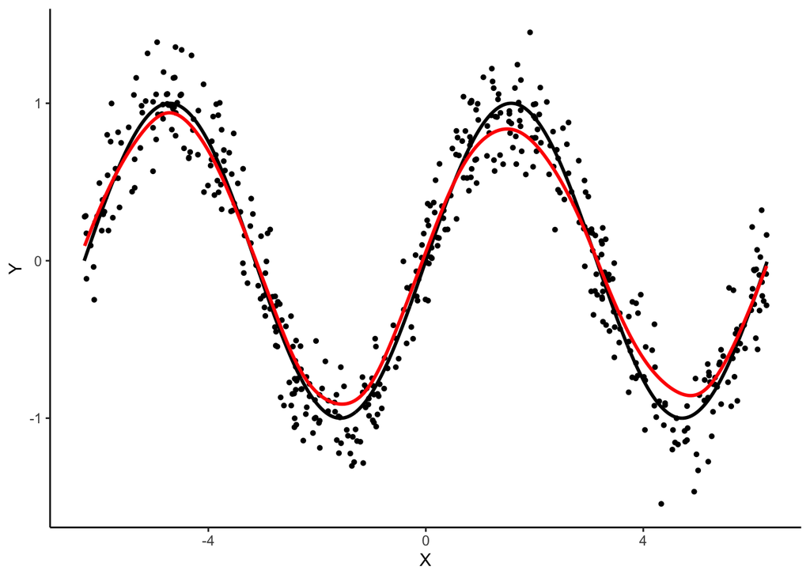

```r
set.seed(1234)
perm <- sample(500,300)
train <- df %>% slice(perm)
test <- df %>% slice(-perm)
h1 <- 0.5
fx1 <-locpoly(train$X,train$Y,bandwidth=h1)
df2 <- data.frame(x=fx1$x,y=fx1$y)
g1+geom_line(data=df2,aes(x=x,y=y),color="red",size=1)
```

4. Add the kernel estimates with bandwidths $h_2=3$ and $h_3=0.01$ (always fitted on the train sample).

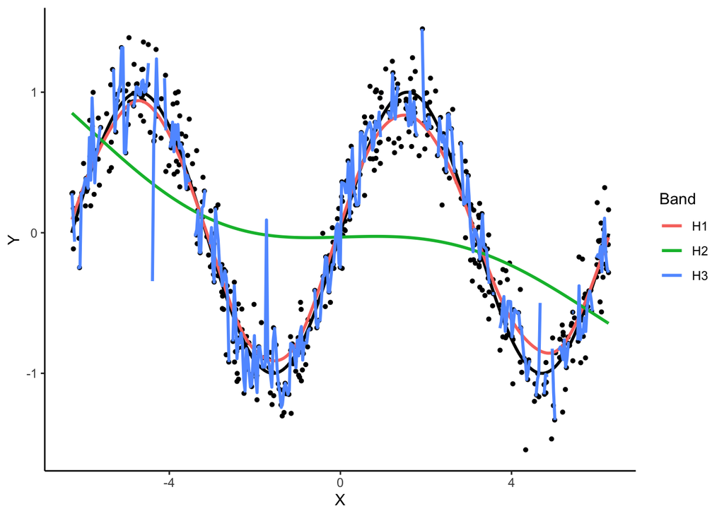

```r
h2 <- 3;h3 <- 0.01
fx2 <-locpoly(train$X,train$Y,bandwidth=h2)
fx3 <-locpoly(train$X,train$Y,bandwidth=h3)
df3 <- data.frame(x=fx1$x,H1=fx1$y,H2=fx2$y,H3=fx3$y) %>%
  gather(key="Band",value="value",-x)
g1+geom_line(data=df3,aes(x=x,y=value,color=Band),size=1)
```

5. Use the test sample to estimate the mean square error of the three kernel estimates. You can use the **ksmooth** function.

```r
test.ord <- test %>% arrange(X)
prev1 <- ksmooth(train$X,train$Y,bandwidth=h1,x.points=test.ord$X)
prev2 <- ksmooth(train$X,train$Y,bandwidth=h2,x.points=test.ord$X)
prev3 <- ksmooth(train$X,train$Y,bandwidth=h3,x.points=test.ord$X)
df5 <- data.frame(H1=prev1$y,H2=prev2$y,H3=prev3$y,obs=test.ord$Y) %>%
   summarise_all(funs(mean((.-obs)^2,na.rm = TRUE))) %>% select(-obs)
#or (better)
data.frame(H1=prev1$y,H2=prev2$y,H3=prev3$y,obs=test.ord$Y) %>%
   summarise_at(vars(H1:H3),~(mean((.-obs)^2,na.rm = TRUE)))
```

| H1 | H2 | H3 |
| --- | --- | --- |
| 0.04675149 | 0.1118099 | 0.08185563 |

## Exercise 5 (ERM with caret)

We again consider the dataset of exercise 1.

```r
dim(my_data)
```

```
## [1] 1000    3
```

```r
set.seed(123)
perm <- sample(nrow(my_data))
train <- my_data %>% slice(perm[1:750])
test <- my_data %>% slice(perm[751:1000])

dim(train)
```

```
## [1] 750   3
```

```r
dim(test)
```

```
## [1] 250   3
```

The goal is to find the best integer $k$ for the $k$-nearest neighbor rule.

1. Fit the 3 nearest-neighbor rule $\widehat g_3$ on the train sample and estimate its error probability
   $$L(\widehat g_3)=\mathbf P(\widehat g_3(X)\neq Y)$$
   by validation hold hout (with the test sample). Use **knn** function from **class** package.

```r
knn3 <- knn(train[,1:2],test[,1:2],cl=train$Y,k=3)
mean(knn3!=test$Y)
```

```
## [1] 0.4
```

2. Estimate the error probability for each value of $k$ in $\{1,\dots,450\}$. You can use a loop **for**:

```r
k.cand <- seq(1,450,by=2)
error <- rep(0,length(k.cand))
set.seed(123)
compt <- 1
for (i in 1:length(k.cand)){
  prev <- knn(train[,1:2],test[,1:2],cl=train$Y,k=k.cand[i])
  error[compt] <- mean(prev!=test$Y)
  compt <- compt+1
}
kopt <- k.cand[which.min(error)]
kopt
```

```
## [1] 31
```

3. Represent the error on a graph: $k$ on the $x$-axis, estimated error on the $y$-axis.

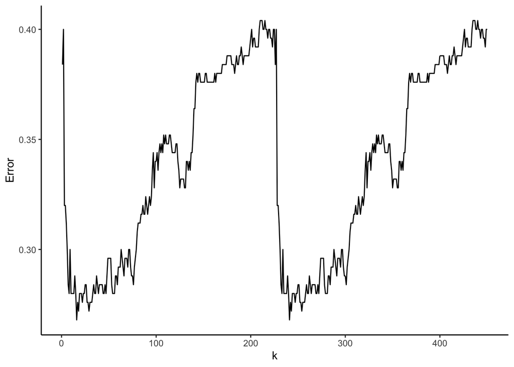

```r
df <- data.frame(k=1:450,Error=error)
ggplot(data=df)+aes(x=k,y=Error)+geom_line()+theme_classic()
```

4. Run the shiny web application in the file **overfitting_app.R**. Explain the results.
5. We propose to use **caret** package to select the best $k$. We can look at http://topepo.github.io/caret/index.html for a presentation of the package. Explain outputs of the commands

```r
#ctrl1 <- trainControl(method="LGOCV",number=1,index=list(1:1500))
ctrl1 <- trainControl(method="LGOCV",number=1)
grid.k <- data.frame(k=seq(1,450,by=2))
sel.k <- train(Y~.,data=my_data,method="knn",trControl=ctrl1,tuneGrid=grid.k)
sel.k
```

```
## k-Nearest Neighbors
##
## 1000 samples
##    2 predictor
##    2 classes: '0', '1'
##
## No pre-processing
## Resampling: Repeated Train/Test Splits Estimated (1 reps, 75%)
## Summary of sample sizes: 751
## Resampling results across tuning parameters:
##
##   k    Accuracy   Kappa
##     1  0.6104418  0.2206447
##     3  0.6425703  0.2875422
##     5  0.6706827  0.3415672
```

[output cut: 225 more lines]

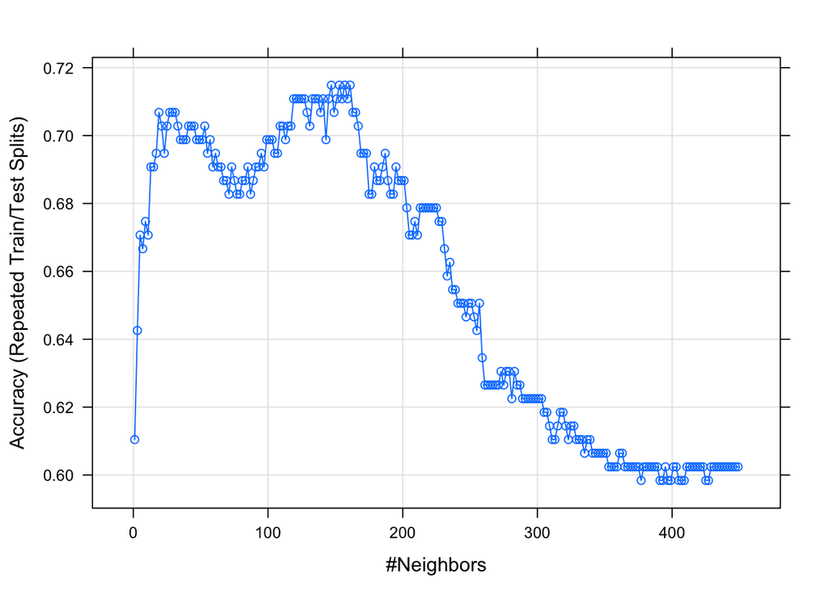

```r
plot(sel.k)
```

We estimate
$$P(\widehat g_k(X)= Y)$$
(column Accuracy) of the $k$nn rules by validation hold out (75% in train, 25% in test).

We can also specify explicitely train and test sets:

```r
ctrl11 <- trainControl(method="LGOCV",number=1,index=list(perm[1:750]))
sel.k1 <- train(Y~.,data=my_data,method="knn",trControl=ctrl11,tuneGrid=grid.k)
sel.k1
```

```
## k-Nearest Neighbors
##
## 1000 samples
##    2 predictor
##    2 classes: '0', '1'
##
## No pre-processing
## Resampling: Repeated Train/Test Splits Estimated (1 reps, 75%)
## Summary of sample sizes: 750
## Resampling results across tuning parameters:
##
##   k    Accuracy  Kappa
##     1  0.616     0.2326384
##     3  0.600     0.1898898
##     5  0.680     0.3475140
```

[output cut: 225 more lines]

We obtain the same result as in question 2.

6. Do the same with 500 observations in the train dataset and 500 observations in the test dataset.

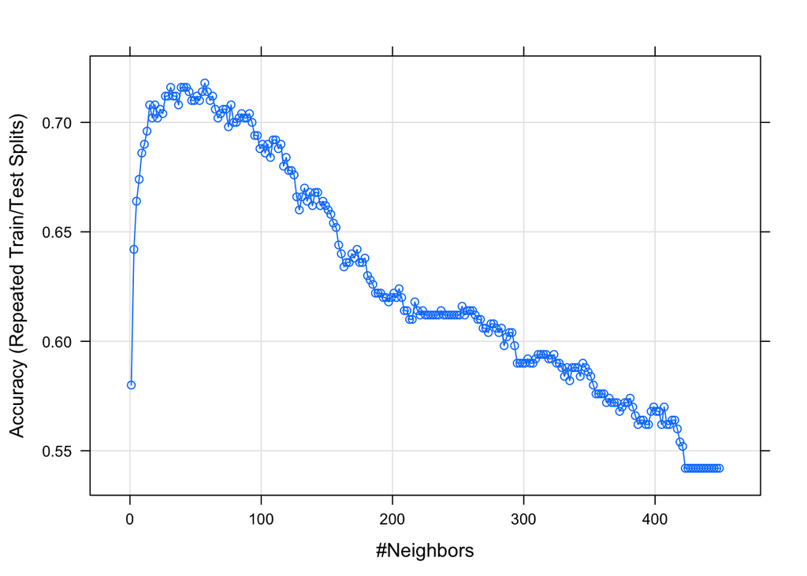

```r
ctrl2 <- trainControl(method="LGOCV",number=1,p=1/2)
sel2.k <- train(Y~.,data=my_data,method="knn",trControl=ctrl2,tuneGrid=grid.k)
#or
ctrl3 <- trainControl(method="LGOCV",number=1,index=list(1:500))
sel3.k <- train(Y~.,data=my_data,method="knn",trControl=ctrl3,tuneGrid=grid.k)
plot(sel3.k)
```

7. Select $k$ by 10 folds cross-validation.

We just have to change parameters **method** in **trainControl**.

```r
ctrl4 <- trainControl(method="cv",number=10)
sel4.k <- train(Y~.,data=my_data,method="knn",trControl=ctrl4,tuneGrid=grid.k)
```

**Remark**: We can use the **doMC** package to parallelize cross-validation:

```r
library(doMC)
detectCores()
```

```
## [1] 8
```

```r
ctrl5 <- trainControl(method="cv",number=50)
registerDoMC(cores = 1)
system.time(sel5.k <- train(Y~.,data=my_data,method="knn",trControl=ctrl5,tuneGrid=grid.k))
```

```
##    user  system elapsed
##  77.371   0.223  77.753
```

```r
registerDoMC(cores = 5)
system.time(sel5.k <- train(Y~.,data=my_data,method="knn",trControl=ctrl5,tuneGrid=grid.k))
```

```
##    user  system elapsed
## 115.254   1.457  26.707
```

Calculations are parallelized on 5 cores. We clearly reduce computation time (if the computer possesses many cores).

8. Explain outputs of these commands.

```r
data1 <- my_data
names(data1)[3] <- c("Class")
levels(data1$Class) <- c("G0","G1")
ctrl11 <- trainControl(method="LGOCV",number=1,index=list(1:750),classProbs=TRUE,summary=twoClassSummary,p=0.66)
aa <- train(Class~.,data=data1,method="knn",trControl=ctrl11,metric="ROC",tuneGrid=grid.k)
aa
```

```
## k-Nearest Neighbors
##
## 1000 samples
##    2 predictor
##    2 classes: 'G0', 'G1'
##
## No pre-processing
## Resampling: Repeated Train/Test Splits Estimated (1 reps, 66%)
## Summary of sample sizes: 750
## Resampling results across tuning parameters:
##
##   k    ROC        Sens       Spec
##     1  0.5908043  0.5409836  0.6406250
##     3  0.6620453  0.5983607  0.6562500
##     5  0.7029329  0.6229508  0.7031250
```

[output cut: 225 more lines]

```r
getTrainPerf(aa)
```

| TrainROC | TrainSens | TrainSpec | method |
| --- | --- | --- | --- |
| 0.7498079 | 0.647541 | 0.796875 | knn |

We consider AUC instead of the error probability (change of criterion).